# Cross-Sectional Momentum on S&P 500 (Kaggle)

Conglin BAO

Nov 5, 2025

## Introduction

We analyze the Kaggle dataset “S&P 500 stock data” (camnugent/sandp500), which ~5 years of daily open, high, low, and close prices and trading volume (OHLCV) in `all_stocks_5yr.csv`. Our objectives are to:  
1: programmatically obtain the data,  
2: clean and aggregate it to monthly log returns,  
3: construct a 12–1 cross-sectional momentum signal,  
4: form decile portfolios and report the long–short (Q10–Q1) performance—annualized return, volatility, Sharpe,  
5: visualize gross vs. cost-adjusted cumulative returns.  
A brief table summarizes sample coverage.

### Table

Sample coverage and momentum long–short performance (gross).

| Sample start | Sample end | Unique tickers | Stock–month observations | Avg monthly long–short (log) | Annualized return | Annualized volatility | Sharpe ratio |
| --- | --- | --- | --- | --- | --- | --- | --- |
| 2014-03 | 2018-02 | 505 | 29,507 | 0.45% | 4.05% | 17.38% | 0.23 |

## Table description:

The table summarizes the sample used in the 12–1 cross-sectional momentum test. We work from March 2014 to February 2018, covering 505 unique S&P-500 tickers and 29,507 stock–months after aggregating daily prices to monthly log returns (last trading day of each month). The equal-weight long–short portfolio (long top decile by momentum, short bottom decile) delivers an average monthly log return of 0.45%, which annualizes to 4.05% with 17.38% annualized volatility, yielding a Sharpe ratio of 0.23. These are gross results (no transaction costs) and reflect a short sample and a simple specification—no industry/size neutrality or turnover control—so they should be viewed as a reproducible baseline rather than an optimized strategy.

### Figure

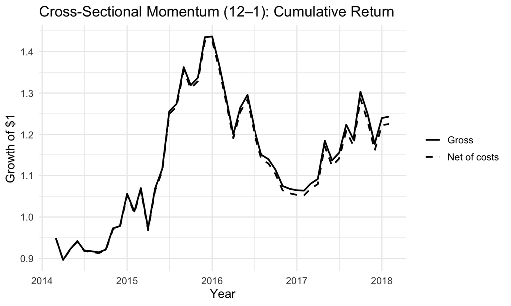

## Figure description:

The figure plots the cumulative wealth of the monthly long–short momentum portfolio starting at $1. The gross curve (solid) and the net-of-costs curve (dashed; 3 bps per side, 50% monthly turnover) track each other closely—costs impose only a small drag under these assumptions. Performance dips in early 2014, rallies through 2015, reaches a local peak around early 2016, then experiences a drawdown into early 2017, followed by a partial recovery; by the end of the sample the portfolio stands near $1.24 gross with a slightly lower net value. This pattern is consistent with momentum cycles over the period and highlights that costs matter but are not dominant with the simple settings used here.